# Testing different model configurations and specifications

## Cargar paquetes

```r
library(tidyverse)
```

# Probar especificacion del modelo

## Leer datos

```r
fish <- read_csv(file = "Test.csv", col_types = cols())
```

## Inspeccionar los datos

```r
skimr::skim(fish)
```

```
Skim summary statistics
 n obs: 48
 n variables: 8

Variable type: character
     variable missing complete  n min max empty n_unique
    Community       0       48 48   1   1     0        2
 GenusSpecies       0       48 48   3   3     0        1
           RC       0       48 48   2   2     0        4
         Site       0       48 48   1   1     0        8
         Zone       0       48 48   7   7     0        2

Variable type: integer
  variable missing complete  n mean   sd p0 p25 median   p75 p100     hist
 Abundance       0       48 48 8.25 4.36  1   5    8   11.25   18 ▇▃▆▇▃▅▂▂
  Transect       0       48 48 2    0.83  1   1    2    3       3 ▇▁▁▇▁▁▁▇
      Year       0       48 48 1.5  0.51  1   1    1.5  2       2 ▇▁▁▁▁▁▁▇
```

## Visualizar datos crudos por Comunidad y par RC

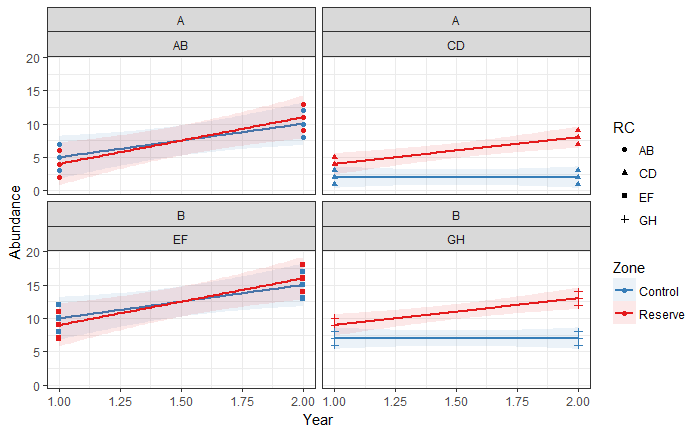

```r
ggplot(fish, aes(x = Year, y = Abundance, color = Zone, fill = Zone, shape = RC)) +
  geom_smooth(method = "lm", alpha = 0.1) +
  geom_point() +
  scale_color_brewer(palette = "Set1", direction = -1) +
  scale_fill_brewer(palette = "Set1", direction = -1) +
  facet_wrap(Community ~ RC) +
  theme_bw()
```

## Calcular promedios por Ano, comunidad, RC y zona

```r
group_by(fish, Community, RC, Year, Zone) %>%
  summarize(mean(Abundance))
```

| Community | RC | Year | Zone | mean(Abundance) |
| --- | --- | --- | --- | --- |
| A | AB | 1 | Control | 5 |
| A | AB | 1 | Reserve | 4 |
| A | AB | 2 | Control | 10 |
| A | AB | 2 | Reserve | 11 |
| A | CD | 1 | Control | 2 |
| A | CD | 1 | Reserve | 4 |
| A | CD | 2 | Control | 2 |
| A | CD | 2 | Reserve | 8 |
| B | EF | 1 | Control | 10 |
| B | EF | 1 | Reserve | 9 |

[output cut: 6 more lines]

## Calcular la diferencia entre antes y despues

```r
group_by(fish, Community, RC, Year, Zone) %>%
  summarize(m = mean(Abundance)) %>%
  spread(Year, m) %>%
  magrittr::set_colnames(value = c("Community", "RC", "Zone", "Before", "After")) %>%
  mutate(Diff = After - Before)
```

| Community | RC | Zone | Before | After | Diff |
| --- | --- | --- | --- | --- | --- |
| A | AB | Control | 5 | 10 | 5 |
| A | AB | Reserve | 4 | 11 | 7 |
| A | CD | Control | 2 | 2 | 0 |
| A | CD | Reserve | 4 | 8 | 4 |
| B | EF | Control | 10 | 15 | 5 |
| B | EF | Reserve | 9 | 16 | 7 |
| B | GH | Control | 7 | 7 | 0 |
| B | GH | Reserve | 9 | 13 | 4 |

## Ajustar el modelo

```r
model1 <- mutate(fish, Year = as.factor(Year)) %>%
  lm(Abundance ~ Year * Zone * RC + 0, data = .)
stargazer::stargazer(model1, type = "html", single.row = T)
```

|  | *Dependent variable:* |
| --- | --- |
|  | Abundance |
| Year1 | 5.000*** (0.913) |
| Year2 | 10.000*** (0.913) |
| ZoneReserve | -1.000 (1.291) |
| RCCD | -3.000** (1.291) |
| RCEF | 5.000*** (1.291) |
| RCGH | 2.000 (1.291) |
| Year2:ZoneReserve | 2.000 (1.826) |
| Year2:RCCD | -5.000*** (1.826) |
| Year2:RCEF | -0.000 (1.826) |
| Year2:RCGH | -5.000*** (1.826) |
| ZoneReserve:RCCD | 3.000 (1.826) |
| ZoneReserve:RCEF | -0.000 (1.826) |
| ZoneReserve:RCGH | 3.000 (1.826) |
| Year2:ZoneReserve:RCCD | 2.000 (2.582) |
| Year2:ZoneReserve:RCEF | 0.000 (2.582) |
| Year2:ZoneReserve:RCGH | 2.000 (2.582) |
| Observations | 48 |
| R<sup>2</sup> | 0.981 |
| Adjusted R<sup>2</sup> | 0.971 |
| Residual Std. Error | 1.581 (df = 32) |
| F Statistic | 102.000*** (df = 16; 32) |
| *Note:* | p<0.1; p<0.05; p<0.01 |

## Probar el modelo

```r
data.frame(Year = as.factor(c(1, 1, 2, 2, 1, 1, 2, 2, 1, 1, 2, 2, 1, 1, 2, 2)),
           Community = c("A","A","A","A","A","A","A","A","B","B","B","B","B","B","B","B"),
           RC = c("AB", "AB", "AB", "AB", "CD", "CD", "CD", "CD", "EF", "EF", "EF", "EF", "GH", "GH", "GH", "GH"),
           Zone = c("Control", "Reserve")) %>%
  mutate(mean = predict(object = model1, .))
```

| Year | Community | RC | Zone | mean |
| --- | --- | --- | --- | --- |
| 1 | A | AB | Control | 5 |
| 1 | A | AB | Reserve | 4 |
| 2 | A | AB | Control | 10 |
| 2 | A | AB | Reserve | 11 |
| 1 | A | CD | Control | 2 |
| 1 | A | CD | Reserve | 4 |
| 2 | A | CD | Control | 2 |
| 2 | A | CD | Reserve | 8 |
| 1 | B | EF | Control | 10 |
| 1 | B | EF | Reserve | 9 |

[output cut: 6 more lines]

Tiene sentido, el promedio predeciro corresponde con los observados de arriba. Carguemos datos nuevos que incluyen un tercer ano

# Probando el modelo con 3 anos

## Cargar datos

```r
fish <- read_csv(file = "Test2.csv", col_types = cols())
```

## Inspeccionar datos

```r
skimr::skim(fish)
```

```
Skim summary statistics
 n obs: 54
 n variables: 8

Variable type: character
     variable missing complete  n min max empty n_unique
    Community       0       54 54   1   1     0        2
 GenusSpecies       0       54 54   3   3     0        1
           RC       0       54 54   2   2     0        4
         Site       0       54 54   1   1     0        8
         Zone       0       54 54   7   7     0        2

Variable type: integer
  variable missing complete  n mean   sd p0 p25 median p75 p100     hist
 Abundance       0       54 54 9.22 5.03  1   6    8.5  13   21 ▆▅▇▆▅▃▃▂
  Transect       0       54 54 2    0.82  1   1    2     3    3 ▇▁▁▇▁▁▁▇
      Year       0       54 54 1.67 0.67  1   1    2     2    3 ▇▁▁▇▁▁▁▂
```

## Visualizar datos crudos por Comunidad y par RC

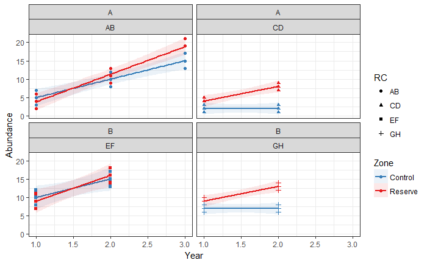

```r
ggplot(fish, aes(x = Year, y = Abundance, color = Zone, fill = Zone, shape = RC)) +
  geom_smooth(method = "lm", alpha = 0.1) +
  geom_point() +
  scale_color_brewer(palette = "Set1", direction = -1) +
  scale_fill_brewer(palette = "Set1", direction = -1) +
  facet_wrap(Community ~ RC) +
  theme_bw()
```

## Ajustar el nuevo modelo.

Tiene la misma estructura, pero los datos tienen 3 anos

```r
model1 <- mutate(fish, Year = as.factor(Year)) %>%
  lm(Abundance ~ Year * Zone * RC + 0, data = .)
stargazer::stargazer(model1, type = "html", single.row = T)
```

|  | *Dependent variable:* |
| --- | --- |
|  | Abundance |
| Year1 | 5.000*** (0.943) |
| Year2 | 10.000*** (0.943) |
| Year3 | 15.000*** (0.943) |
| ZoneReserve | -1.000 (1.333) |
| RCCD | -3.000** (1.333) |
| RCEF | 5.000*** (1.333) |
| RCGH | 2.000 (1.333) |
| Year2:ZoneReserve | 2.000 (1.886) |
| Year3:ZoneReserve | 5.000** (1.886) |
| Year2:RCCD | -5.000** (1.886) |
| Year3:RCCD |  |
| Year2:RCEF | 0.000 (1.886) |
| Year3:RCEF |  |
| Year2:RCGH | -5.000** (1.886) |
| Year3:RCGH |  |
| ZoneReserve:RCCD | 3.000 (1.886) |
| ZoneReserve:RCEF | 0.000 (1.886) |
| ZoneReserve:RCGH | 3.000 (1.886) |
| Year2:ZoneReserve:RCCD | 2.000 (2.667) |
| Year3:ZoneReserve:RCCD |  |
| Year2:ZoneReserve:RCEF | -0.000 (2.667) |
| Year3:ZoneReserve:RCEF |  |
| Year2:ZoneReserve:RCGH | 2.000 (2.667) |
| Year3:ZoneReserve:RCGH |  |
| Observations | 54 |
| R<sup>2</sup> | 0.984 |
| Adjusted R<sup>2</sup> | 0.976 |
| Residual Std. Error | 1.633 (df = 36) |
| F Statistic | 121.625*** (df = 18; 36) |
| *Note:* | p<0.1; p<0.05; p<0.01 |

## Probar el modelo

```r
data.frame(Year = as.factor(c(3)),
           Community = c("A"),
           RC = c("AB"),
           Zone = c("Control", "Reserve")) %>%
  mutate(mean = predict(object = model1, .))
```

```
prediction from a rank-deficient fit may be misleading
```

| Year | Community | RC | Zone | mean |
| --- | --- | --- | --- | --- |
| 3 | A | AB | Control | 15 |
| 3 | A | AB | Reserve | 19 |

Las predicciones son correctas, pues coinciden con los valores promedios del tercer ano en los datos crudos:

```r
filter(fish, Year == 3) %>%
  group_by(RC, Zone) %>%
  summarize(mean = mean(Abundance))
```

| RC | Zone | mean |
| --- | --- | --- |
| AB | Control | 15 |
| AB | Reserve | 19 |

## Visualicemos los efectos del modelo.

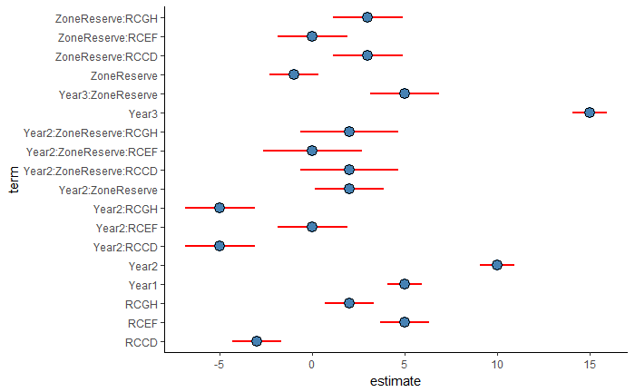

```r
broom::tidy(model1) %>%
  ggplot(aes(x = term, y = estimate)) +
  geom_errorbar(aes(ymin = estimate - std.error, ymax = estimate + std.error), width = 0, color = "red", size = 1) +
  geom_point(fill = "steelblue", size = 4, shape = 21, color = "black") +
  coord_flip() +
  theme_classic()
```

# Probar efectos fijos por ano vs. pre-post

Usemos los mismos datos, pero solamente la comunidad A para comparar Pre-Post vs. Efectos fijos por ano

## Primero efectos fijos por ano:

```r
(test_results <- filter(fish, Community == "A") %>%
  mutate(Year = as.factor(Year)) %>%
  lm(Abundance ~ Year * Zone * RC + 0, data = .) %>%
  broom::tidy())
```

| term | estimate | std.error | statistic | p.value |
| --- | --- | --- | --- | --- |
| Year1 | 5 | 0.9660918 | 5.1754917 | 4.597529e-05 |
| Year2 | 10 | 0.9660918 | 10.3509834 | 1.765739e-09 |
| Year3 | 15 | 0.9660918 | 15.5264751 | 1.271709e-12 |
| ZoneReserve | -1 | 1.3662601 | -0.7319251 | 4.727046e-01 |
| RCCD | -3 | 1.3662601 | -2.1957752 | 4.007195e-02 |
| Year2:ZoneReserve | 2 | 1.9321836 | 1.0350983 | 3.129774e-01 |
| Year3:ZoneReserve | 5 | 1.9321836 | 2.5877458 | 1.758662e-02 |
| Year2:RCCD | -5 | 1.9321836 | -2.5877458 | 1.758662e-02 |
| ZoneReserve:RCCD | 3 | 1.9321836 | 1.5526475 | 1.361888e-01 |
| Year2:ZoneReserve:RCCD | 2 | 2.7325202 | 0.7319251 | 4.727046e-01 |

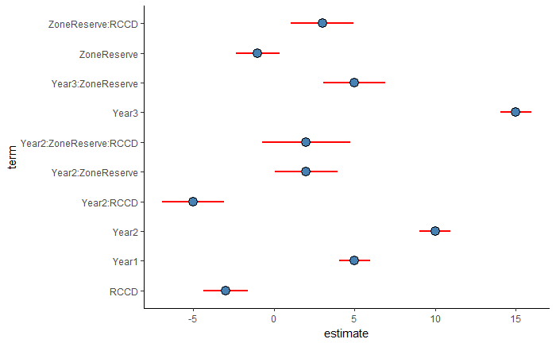

```r
ggplot(test_results, aes(x = term, y = estimate)) +
  geom_errorbar(aes(ymin = estimate - std.error, ymax = estimate + std.error), width = 0, color = "red", size = 1) +
  geom_point(fill = "steelblue", size = 4, shape = 21, color = "black") +
  coord_flip() +
  theme_classic()
```

## Ahora modificando Ano para tener pre y post:

```r
(test_results <- filter(fish, Community == "A") %>%
  mutate(Year = as.factor(ifelse(Year == 1, "A", "D"))) %>%
  lm(Abundance ~ Year * Zone * RC + 0, data = .) %>%
  broom::tidy())
```

| term | estimate | std.error | statistic | p.value |
| --- | --- | --- | --- | --- |
| YearA | 5.0 | 1.694465 | 2.9507836 | 7.389434e-03 |
| YearD | 12.5 | 1.198168 | 10.4325956 | 5.555456e-10 |
| ZoneReserve | -1.0 | 2.396336 | -0.4173038 | 6.805004e-01 |
| RCCD | -3.0 | 2.396336 | -1.2519115 | 2.237493e-01 |
| YearD:ZoneReserve | 3.5 | 2.934900 | 1.1925450 | 2.457519e-01 |
| YearD:RCCD | -7.5 | 3.170054 | -2.3658903 | 2.721558e-02 |
| ZoneReserve:RCCD | 3.0 | 3.388930 | 0.8852351 | 3.856034e-01 |
| YearD:ZoneReserve:RCCD | 0.5 | 4.483133 | 0.1115291 | 9.122081e-01 |

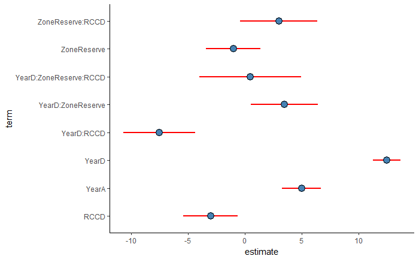

```r
ggplot(test_results, aes(x = term, y = estimate)) +
  geom_errorbar(aes(ymin = estimate - std.error, ymax = estimate + std.error), width = 0, color = "red", size = 1) +
  geom_point(fill = "steelblue", size = 4, shape = 21, color = "black") +
  coord_flip() +
  theme_classic()
```

Perdemos los terminos del Ano2 = 10 y Ano3 = 15, Ano2:Reserva = 2 y Ano3:Reserva = 5, y terminamos con AnoD = 12.5 y AnoD:Reserva, que son los promedios entre los perdidos, respectivamente. Esta forma de modelarlo nos dice el efecto PROMEDIO de la reserva, que podria subestimar el efecto real. Es mejor usar los efectos fijos por ano.

Que pasa si tenemos reservas que comienzan en diferentes anos?

# Reservas con anos diferentes

```r
fish <- read_csv(file = "Test3.csv", col_types = cols())
```

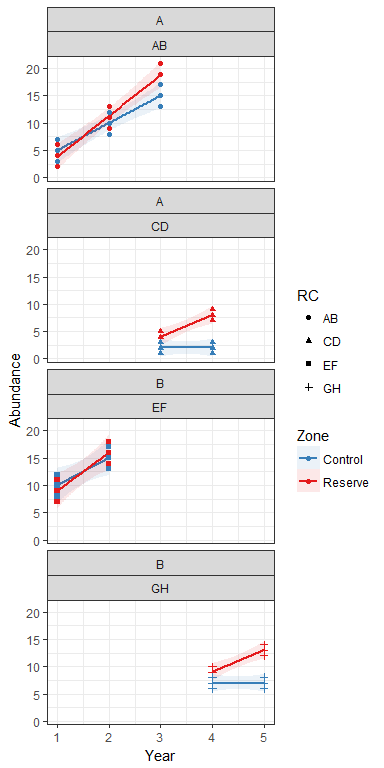

```r
ggplot(fish, aes(x = Year, y = Abundance, color = Zone, fill = Zone, shape = RC)) +
  geom_smooth(method = "lm", alpha = 0.1) +
  geom_point() +
  scale_color_brewer(palette = "Set1", direction = -1) +
  scale_fill_brewer(palette = "Set1", direction = -1) +
  facet_wrap(Community ~ RC, ncol = 1) +
  theme_bw()
```

```r
model1 <- mutate(fish, Year = as.factor(Year)) %>%
  lm(Abundance ~ Year * Zone * RC + 0, data = .)
stargazer::stargazer(model1, type = "html", single.row = T)
```

|  | *Dependent variable:* |
| --- | --- |
|  | Abundance |
| Year1 | 5.000*** (0.943) |
| Year2 | 10.000*** (0.943) |
| Year3 | 15.000*** (0.943) |
| Year4 | 15.000*** (1.633) |
| Year5 | 15.000*** (2.108) |
| ZoneReserve | -1.000 (1.333) |
| RCCD | -13.000*** (1.333) |
| RCEF | 5.000*** (1.333) |
| RCGH | -8.000*** (1.886) |
| Year2:ZoneReserve | 2.000 (1.886) |
| Year3:ZoneReserve | 5.000** (1.886) |
| Year4:ZoneReserve | 9.000*** (2.667) |
| Year5:ZoneReserve | 13.000*** (3.266) |
| Year2:RCCD |  |
| Year3:RCCD |  |
| Year4:RCCD |  |
| Year5:RCCD |  |
| Year2:RCEF | 0.000 (1.886) |
| Year3:RCEF |  |
| Year4:RCEF |  |
| Year5:RCEF |  |
| Year2:RCGH |  |
| Year3:RCGH |  |
| Year4:RCGH |  |
| Year5:RCGH |  |
| ZoneReserve:RCCD | -2.000 (1.886) |
| ZoneReserve:RCEF | 0.000 (1.886) |
| ZoneReserve:RCGH | -6.000** (2.667) |
| Year2:ZoneReserve:RCCD |  |
| Year3:ZoneReserve:RCCD |  |
| Year4:ZoneReserve:RCCD |  |
| Year5:ZoneReserve:RCCD |  |
| Year2:ZoneReserve:RCEF | -0.000 (2.667) |
| Year3:ZoneReserve:RCEF |  |
| Year4:ZoneReserve:RCEF |  |
| Year5:ZoneReserve:RCEF |  |
| Year2:ZoneReserve:RCGH |  |
| Year3:ZoneReserve:RCGH |  |
| Year4:ZoneReserve:RCGH |  |
| Year5:ZoneReserve:RCGH |  |
| Observations | 54 |
| R<sup>2</sup> | 0.984 |
| Adjusted R<sup>2</sup> | 0.976 |
| Residual Std. Error | 1.633 (df = 36) |
| F Statistic | 121.625*** (df = 18; 36) |
| *Note:* | p<0.1; p<0.05; p<0.01 |

```r
data.frame(Year = as.factor(c(3)),
           Community = c("A"),
           RC = c("AB"),
           Zone = c("Control", "Reserve")) %>%
  mutate(mean = predict(object = model1, .))
```

```
prediction from a rank-deficient fit may be misleading
```

| Year | Community | RC | Zone | mean |
| --- | --- | --- | --- | --- |
| 3 | A | AB | Control | 15 |
| 3 | A | AB | Reserve | 19 |

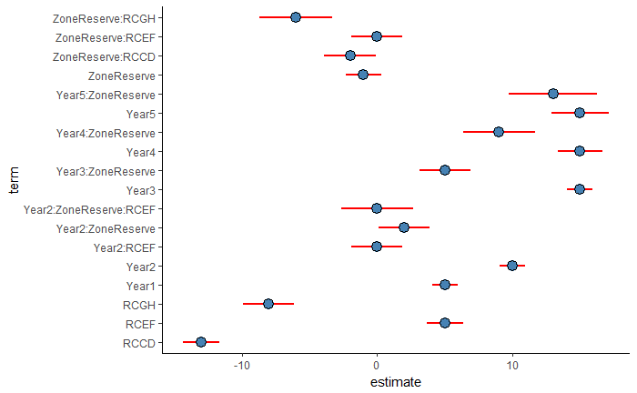

```r
broom::tidy(model1) %>%
  ggplot(aes(x = term, y = estimate)) +
  geom_errorbar(aes(ymin = estimate - std.error, ymax = estimate + std.error), width = 0, color = "red", size = 1) +
  geom_point(fill = "steelblue", size = 4, shape = 21, color = "black") +
  coord_flip() +
  theme_classic()
```

# Como completar los datos?

```r
df <- read_csv(file = "Test4.csv", col_types = cols())
```

```r
skimr::skim(df)
```

```
Skim summary statistics
 n obs: 8
 n variables: 7

Variable type: character
     variable missing complete n min max empty n_unique
    Community       0        8 8   1   1     0        1
 GenusSpecies       0        8 8   1   1     0        8
         Site       0        8 8   1   1     0        2
         Zone       0        8 8   7   7     0        2

Variable type: integer
  variable missing complete n mean   sd p0  p25 median  p75 p100     hist
 Abundance       0        8 8  2   0.76  1 1.75    2   2.25    3 ▃▁▁▇▁▁▁▃
  Transect       0        8 8  1.5 0.53  1 1       1.5 2       2 ▇▁▁▁▁▁▁▇
      Year       0        8 8  1.5 0.53  1 1       1.5 2       2 ▇▁▁▁▁▁▁▇
```

```r
complete(df, Year, Community, Transect, nesting(Site, Zone, GenusSpecies), fill = list(Abundance = 0)) %>%
  select(Year, Community, Site, Zone, Transect, GenusSpecies, Abundance) %>%
  arrange(Year, Community, Site, Zone, Transect, GenusSpecies)
```

| Year | Community | Site | Zone | Transect | GenusSpecies | Abundance |
| --- | --- | --- | --- | --- | --- | --- |
| 1 | A | A | Control | 1 | A | 1 |
| 1 | A | A | Control | 1 | B | 0 |
| 1 | A | A | Control | 1 | H | 0 |
| 1 | A | A | Control | 1 | I | 0 |
| 1 | A | A | Control | 2 | A | 0 |
| 1 | A | A | Control | 2 | B | 2 |
| 1 | A | A | Control | 2 | H | 0 |
| 1 | A | A | Control | 2 | I | 0 |
| 1 | A | B | Reserve | 1 | C | 2 |
| 1 | A | B | Reserve | 1 | D | 0 |

[output cut: 22 more lines]